# Black Thursday sulla blockchain

## Struttura della rete

Nodi e archi

Ogni indirizzo Ethereum è un nodo. Ogni coppia di indirizzi che interagisce è un arco orientato, da chi invia a chi riceve.

Due pesi

Su ogni arco due pesi: quante transazioni (**n_tx**) e quanti ETH mossi (**eth**) sono passati tra i due indirizzi.

Un giorno

Giovedì 12 marzo 2020, il giorno del crollo dei mercati per il Covid.

- Per ogni blocco viene inoltrata una richiesta ad un endpoint pubblico di Alchemy con la chiamata JSON-RPC `eth_getBlockByNumber`, che restituisce tutte le transazioni del blocco. In totale sono stati scaricati 6.448 blocchi, con 760.781 transazioni.

## Tipi di chiamate e costruzione della rete

Le transazioni sono principalmente di due tipi: trasferimenti di ETH e chiamate a contratti. Un trasferimento sposta ETH da un indirizzo a un altro mentre una chiamata a contratto permette di interagire con smart contracts per scambio di token, votazioni o aste e raramente muovono direttamente ETH. Il grafico mostra quante sono e quanti ETH muovono.

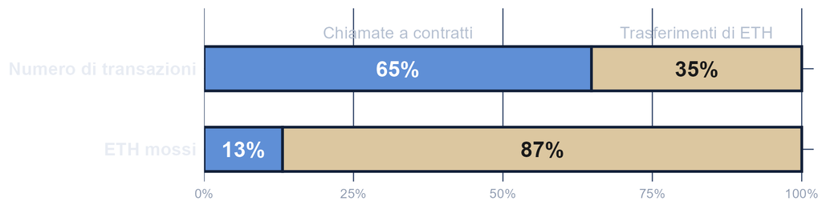

La differenza sostanziale tra le due tipologie di transazioni richiede che vengano creati due grafi distinti per permettere una migliore analisi delle caratteristiche.

| Rete | Cosa contiene | Nodi | Archi | Grado medio | Componente maggiore | Reciprocità |
| --- | --- | --- | --- | --- | --- | --- |
| Rete A | Comprende tutte le transazioni, sia trasferimenti di ETH che chiamate a contratti (rete completa). | 250.074 | 328.967 | 2,63 | 90% | 0,9% |
| Rete B | Solo i trasferimenti diretti di ETH, rappresenta principalmente portafogli ed exchange | 187.103 | 206.987 | 2,21 | 75% | 1,4% |

## Parte 1: analisi della rete

Gradi, distanze, resilienza, comunità

## Quantificazione dei collegamenti

Il grafico mostra, per ogni valore k, la percentuale di indirizzi che hanno almeno k collegamenti (grado ≥ k), in scala logaritmica.

[interactive chart not shown]

305

asimmetria del grado  
(0 = simmetrica)

2,0

esponente della legge di potenza

- A causa della grande asimmetria per visualizzare al meglio la legge di potenza è stato necessario misurare quanti nodi hanno grado ≥ k: la curva è continua e sempre decrescente e la pendenza ne dà l’esponente.
- In scala logaritmica la cumulata è quasi una retta (R² = 0,98) e la pendenza dà un esponente α ≈ 2,0, che rientra (al limite basso) nell’intervallo tipico delle reti scale-free, tra 2 e 3. La distribuzione dei gradi è quindi molto simile a una power law, anche se, come accade spesso nelle reti reali, vale soprattutto nella coda, cioè per i pochi hub con moltissimi collegamenti.

## Distanza media e diametro

Misure calcolate sulle reti A e B, ignorando la direzione degli archi. Per motivi di tempo i calcoli sono stati fatti con 2.000 indirizzi casuali, quindi il diametro è leggermente sottostimato.

| Rete | Distanza media | Diametro | Transitività | Assortatività (log) |
| --- | --- | --- | --- | --- |
| Rete A | 5,29 | ≥ 21 | 0,00007 | -0,55 |
| Rete B | 5,95 | ≥ 22 | 0,00004 | -0,49 |

- Una distanza media di 5,3 è bassa nonostante i 250.074 indirizzi, quindi la rete ha caratteristiche di smallworldness; il diametro è però molto alto, quindi alcune coppie di indirizzi risultano molto distanti.
- La transitività è quasi zero e l’assortatività è negativa quindi gli hub si collegano a indirizzi con pochi collegamenti e raramente tra loro; ulteriore conferma di una rete a stella, con pochi hub al centro e tanti indirizzi ai margini.

## Vulnerabilità a guasti e attacchi mirati

Visto che la rete è a stella, verifichiamo che un attacco mirato destabilizzi la struttura come da teoria: nella rete B togliamo gli indirizzi con più collegamenti e, per confronto, lo stesso numero di indirizzi scelti a caso. Il grafico mostra quanti indirizzi restano collegati tra loro (la componente maggiore, in percentuale della rete) man mano che se ne tolgono di più.

[interactive chart not shown]

- La rete resiste ai guasti casuali ma è fragile agli attacchi mirati ed è la conferma della struttura a stella. Trattandosi però di una blockchain il significato di un eventuale attacco che disattiva i nodi principali è molto differente da una rete classica e per capire in che modo bisogna analizzare l’identità dei nodi (nella parte 2)

## Chi ha più collegamenti non muove più ETH

Finora gli archi non sono stati pesati, ora operiamo sulla rete completa in due modi: un peso come numero di transazioni ed uno come ETH mossi, usando la rete A perché più significativa per questo tipo di analisi.

Per ogni indirizzo vengono contati i collegamenti (con quanti indirizzi diversi comunica), il numero di transazioni singole (quante ne invia e ne riceve, tra trasferimenti e chiamate a contratti) e gli ETH mossi (quelli inviati e ricevuti). È possibile poi creare delle classifiche per misurazione e confrontarle con la correlazione di rango di Spearman.

Correlazione di rango di Spearman: 1 = stessa classifica, 0 = nessun legame

| Classifiche confrontate | Correlazione |
| --- | --- |
| Collegamenti e transazioni | 0,84 |
| Collegamenti ed ETH mossi | 0,37 |
| Transazioni ed ETH mossi | 0,26 |

- Chi ha più collegamenti fa anche più transazioni (0,84), ma non muove più ETH (0,37): anche le classifiche delle transazioni e degli ETH mossi sono molto diverse (0,26).
- Ad esempio, l’indirizzo con più collegamenti ne ha 30.908 e fa 113.718 transazioni, ma muove 0 ETH; un altro con soli 2 collegamenti muove 241.052 ETH.

## Rilevamento comunità

Una comunità è un gruppo di indirizzi più collegati tra loro che con il resto della rete. Sono state cercate con il metodo di Louvain, che mette a confronto la rete connettività di eventuali cluster rispetto ad una rete casuale, sulla rete A, pesandola nei due modi precedentemente descritti.

Separazione comunità (0 = nessuna, 1 = netta)

[output not shown]

- In entrambi i casi le comunità sono ben separate: con il peso n_tx il 91% delle transazioni avviene tra indirizzi della stessa comunità, con il peso eth l’87% della moneta si sposta dentro una comunità.
- Nonostante la separazione sia comparabile, la similarità tra le due è molto bassa: i due pesi mettono in evidenza hub differenti.
- Il motivo è, ancora, che il 33% degli archi non muove ETH: quasi tutti sono chiamate a contratti. Con il peso ETH questi collegamenti valgono zero e non tengono più uniti i 56.741 indirizzi che hanno solo collegamenti di questo tipo che restano quindi isolati, creando comunità da un singolo nodo.

## Parte 2: analisi dei nodi

A chi appartengono gli indirizzi.

## I dieci hub più grandi: token, pool di mining ed exchange

Tramite Etherscan, sito che permette di analizzare le transazioni sulla blockchain Ethereum, è stato possibile associare un nome ai nodi più centrali del grafo.

| Indirizzo | Collegamenti | Transazioni (n_tx) | ETH mossi |
| --- | --- | --- | --- |
| USDT | 30.908 | 113.718 | 0 |
| Ethermine | 16.011 | 16.011 | 3.757 |
| Binance | 7.900 | 13.620 | 790.618 |
| USDC | 5.910 | 11.697 | 0 |
| Nanopool | 4.545 | 5.416 | 1.425 |
| DAI | 3.533 | 6.352 | 0 |
| 0x7c06a6… | 3.392 | 3.410 | 14 |
| Spark Pool | 3.047 | 3.100 | 10.535 |
| LINK | 3.043 | 7.619 | 20 |
| F2Pool | 2.776 | 2.776 | 1.426 |

pool di mining exchange contratti/token non identificato

- Al contrario di una rete classica gli hub qui non sono semplici privati che scambiano grandi quantità di Ethereum ma sono contratti molto utilizzati per token (USDT, USDC, DAI, LINK) o exchange (Binance).

## Hub visualizzati

Visualizzando graficamente gli hub: ogni bolla è uno dei 20 indirizzi più connessi della rete completa, la grandezza è il numero di indirizzi collegati e la parte piena i nodi di grado 1, che senza l’hub resterebbero soli.

[interactive chart not shown]

pool di mining exchange token e scambi non identificato

- Per i pool di mining circa il 73% dei collegati dipende dall’hub, per Binance solo il 5%: la stella è più evidente nei pool piuttosto che negli exchange.

## Per numero di transazioni gli hub sono i contratti, per ETH gli exchange

Il PageRank misura l’importanza di un nodo in base all’importanza di chi lo collega. Il grafico mostra i dieci indirizzi con il PageRank più alto nella rete A, con archi pesati dal numero di transazioni (a sinistra) o dagli ETH mossi (a destra).

[interactive chart not shown]

token e scambi exchange non identificato

- Come ci si può aspettare ci sono molti collegamenti a smart contract popolari (come Tether) e cambiare il peso degli archi mette in evidenza gli exchange, dove avviene lo scambio diretto di moneta.
- Si nota anche che molti exchange hanno più indirizzi (es. Binance 2/3/4): sono necessari per non tenere tutti i fondi nello stesso indirizzo, mantenere la privacy degli utenti (aumentando la difficoltà nel tracciamento delle transazioni) e per gestire più prelievi in parallelo; in una giornata di crisi come quella analizzata questo risulta ancora più utile.

## Exchange e pool di mining

Sappiamo che la rete B esclude i contratti, abbiamo quindi che i 15 indirizzi con più collegamenti sono i seguenti:

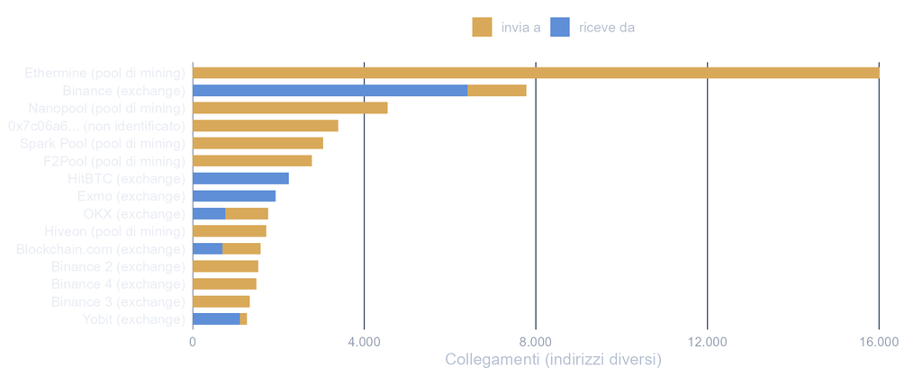

## L’indirizzo non identificato: 3.410 trasferimenti identici da 0,004 ETH

Uno degli indirizzi precedenti non ha trovato riscontro su Etherscan: ha grado 3.392 ma muove solo 14 ETH, si comporta in modo diverso sia dagli exchange che dai pool.

- Invia 3.410 trasferimenti, tutti di esattamente 0,004 ETH e con un prezzo poco variabile del gas (perlopiù 18 gwei), raramente due volte allo stesso indirizzo, senza ricevere nulla per tutto il giorno.
- Controllando alcuni destinatari su Etherscan, prima ricevono USDT da portafogli di un exchange e pochi minuti dopo arrivano 0,004 ETH ed in seguito mandano USDT e ETH a due indirizzi collettori: i 0,004 ETH servono quindi a pagare il gas per spostare l’USDT.
- È quindi con ogni probabilità un distributore di gas per gli indirizzi di deposito di un exchange: questo fa capire come le possibili funzioni dei nodi siano estremamente varie.

## Contratti

Torniamo ai contratti, che dominano per numero di transazioni: il grafico mostra la percentuale delle chiamate che ricevono i 10 contratti più utilizzati.

[interactive chart not shown]

- I 4 token (USDT, USDC, LINK, DAI) sono chiamati da migliaia di indirizzi, poche volte ciascuno.
- Gli altri 6 sono chiamati da pochi indirizzi (al massimo 585), ma molte volte ciascuno (in media almeno 13 chiamate a testa).
- I pochi indirizzi che ripetono tante chiamate sono riconducibili a bot automatici per la partecipazione alle aste o per il semplice trading.
- Un esempio sono i due contratti non identificati: uno legge i prezzi di Uniswap e Kyber, probabilmente per fare arbitraggio, mentre l’altro scambia diversi token (DAI, WETH, USDC) come un portafoglio bot.

## Comunità

Mettendo insieme i diversi tipi di hub visti finora e l’identità dei nodi, possiamo rivisitare le comunità della parte 1. La tabella dice quanti indirizzi ha la comunità di quattro hub, con il peso n_tx e con il peso ETH.

| Hub | Indirizzi nella comunità (peso n_tx) | Indirizzi nella comunità (peso ETH) |
| --- | --- | --- |
| USDT | 34.829 | 1 |
| Binance | 21.735 | 19.463 |
| Ethermine | 28.229 | 28.263 |
| Nanopool | 28.229 | 28.263 |

- Con il peso n_tx le tre comunità più grandi sono quelle di USDT, di Ethermine/Nanopool (i miner usano gli stessi exchange) e di Binance, ognuna centrata su un hub con i suoi clienti.
- Con il peso ETH la comunità di USDT si riduce a un solo indirizzo, perché i suoi archi valgono 0 ETH. Quelle di Binance, Ethermine/Nanopool, che muovono ETH, restano praticamente identiche: i pool pagano ogni indirizzo una sola volta, quindi nessuno dei due pesi ne spezza la stella.

## Parte 3: analisi giornata

La giornata del crollo di Ethereum a causa del covid: cambia la morfologia della rete o cambia solo l’attività?

## Prezzo del gas in gwei

Il grafico mostra il prezzo del gas mediano, cioè quanta moneta eth si è disposti a pagare per far eseguire una transazione in un determinato blocco.

[interactive chart not shown]

|  | Transazioni | Gas medio |
| --- | --- | --- |
| 00-06 | 206.965 | 16 |
| 06-12 | 183.818 | 47 |
| 12-18 | 174.924 | 170 |
| 18-24 | 195.074 | 90 |

- Dalle 12 alle 17 il gas non scende mai sotto i 106 gwei; poi dimezza, ma in serata resta intorno a 71, molto sopra i valori del mattino.
- Il numero di transazioni non è strettamente correlato al prezzo del gas, infatti la finestra con il prezzo gas più alto (12-18) è quella che ne ha meno (174.924).
- Essendo il gas l’offerta per entrare in un blocco ed essendo lo spazio limitato il prezzo sale quando gli utenti hanno fretta, come nel pomeriggio durante il crollo, non necessariamente quando le transazioni sono più numerose.

## Struttura della rete nel tempo

La morfologia della rete cambia durante la giornata? Il grafico mostra il numero di collegamenti di alcuni hub in ciascuna finestra di 6 ore

[interactive chart not shown]

- La struttura regge: la componente maggiore resta tra l’80% e l’83% degli indirizzi in tutte le finestre.
- Cambiano però gli hub attivi, ad esempio F2Pool è attivo soltanto nelle ore notturne, Spark Pool e Hiveon solo al mattino.
- Il motivo è nel metodo di pagamento: F2Pool, Spark Pool e Hiveon pagano i miner in un’unica serie di movimenti concentrati in poche ore (notte/mattina), Ethermine invece paga lungo tutta la giornata.
- Inoltre è possibile notare un picco di attività di Binance in concomitanza con il crollo, anche se mi aspettavo un aumento maggiore.

## Confronto con altre giornate

Per avere più informazioni è stata ripetuta l’analisi per il giorno del 5 Marzo 2020, ovvero una settimana prima del crollo, e con una data vicina al presente (23/10/2026). Nel primo caso la struttura rimane simile e come atteso diminuisce sia il costo mediano del gas che il numero di ETH mossi. Nel secondo caso, essendo passati 6 anni, molti degli hub sono inattivi o hanno cambiato indirizzo.

| Hub | Collegamenti 5 marzo | Collegamenti 12 marzo | Stato oggi | Ultima transazione inviata |
| --- | --- | --- | --- | --- |
| USDT | 43.415 | 30.908 | Attivo | In corso |
| USDC | 2.915 | 5.910 | Attivo | In corso |
| Ethermine | 13.777 | 16.011 | Chiuso | 17 giorni fa |
| Binance | 3.718 | 7.900 | Cambio indirizzo | 1+ anni fa |
| Nanopool | 5.178 | 4.545 | Chiuso | 3+ anni fa |
| Spark Pool | 2.984 | 3.047 | Chiuso | 5+ anni fa |
| F2Pool | 2.748 | 2.776 | Chiuso | 80 giorni fa |
| Hiveon | 1.587 | 1.712 | Cambio indirizzo | 6+ anni fa |

- I pool di mining hanno chiuso principalmente per il passaggio al metodo proof-of-stake.
- Ethermine e F2Pool mostrano ancora qualche transazione: sono probabilmente pagamenti dei saldi rimasti ai miner; Nanopool opera ancora ma estrae altre criptovalute (Ethereum Classic), quindi su questo indirizzo non ha più movimenti.
- In sintesi, tra una giornata calma e il crollo la struttura rimane simile e cambia solo l’attività, mentre a sei anni di distanza sono cambiati gli hub: restano attivi solo i contratti dei token (USDT, USDC).

Disclaimer sull’uso dell’AI: il codice è stato in parte generato con Claude e poi corretto a mano. Le scelte di progetto (idee, direzione, giornate da analizzare) e le interpretazioni dei risultati sono personali.